# Milestones 4 -- Interpretation of data

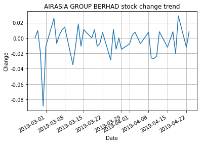

```python
# Daily return visualization
C_stock1['change'].plot(grid = True)
plt.title('AIRASIA GROUP BERHAD stock change trend')
plt.xlabel('Date')
plt.ylabel('Change')
```

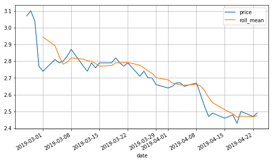

```python
# Plot price and 5 day moving average
s_p_m1 = C_stock1.copy(deep=True)
s_p_m1['roll_mean'] = s_p_m1['price'].rolling(window=5).mean()
s_p_m1[['price', 'roll_mean']].plot(subplots=False, figsize=(9, 5), grid=True)
```

- Line segment chart is feasible, but the data for each day has at least four variables (opening, stock price, stock price and closing), We hope to find a visualization that does not require us to draw four different lines to see the trend of these four variables. In general, we use the candlestick chart (also known as the Japanese candlestick chart) to visualize financial data. The candlestick chart was first used by Japanese rice merchants in the 18th century.

```python
from pandas import DataFrame, Series
import pandas as pd; import numpy as np
import matplotlib.pyplot as plt
from matplotlib import dates as mdates
from matplotlib import ticker as mticker
from mpl_finance import candlestick_ohlc
from matplotlib.dates import DateFormatter, WeekdayLocator, DayLocator, MONDAY,YEARLY
from matplotlib.dates import MonthLocator,MONTHLY
import datetime
import pylab
```

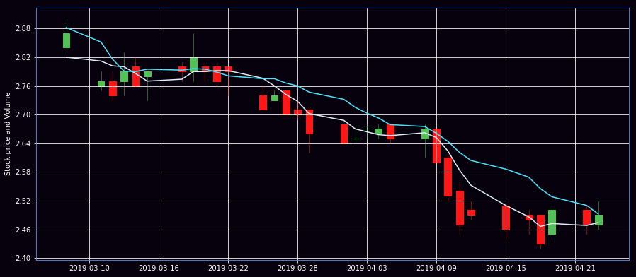

```python
from pandas import DataFrame, Series
import pandas as pd; import numpy as np
import matplotlib.pyplot as plt
from matplotlib import dates as mdates
from matplotlib import ticker as mticker
from mpl_finance import candlestick_ohlc
from matplotlib.dates import DateFormatter, WeekdayLocator, DayLocator, MONDAY,YEARLY
from matplotlib.dates import MonthLocator,MONTHLY
import datetime
import pylab

MA1 = 5# The date interval of the moving average
MA2 = 10
startdate = datetime.date(2019,2,25)
enddate = datetime.date(2019,4,23)
data=pd.DataFrame(C_stock1)
stdata=pd.DataFrame({'DateTime':data.index,'Open':data.open,'High':data.high,'Close':data.price,'Low':data.low})
stdata['DateTime'] = mdates.date2num(stdata['DateTime'].astype(datetime.date))

def main():
    daysreshape = stdata.reset_index()
    daysreshape = daysreshape.reindex(columns=['DateTime', 'Open', 'High', 'Low', 'Close'])

    Av1 = daysreshape['Close'].rolling(window=MA1).mean()
    Av2 = daysreshape['Close'].rolling(window=MA2).mean()
    SP = len(daysreshape.DateTime.values[MA2 - 1:])
    fig = plt.figure(facecolor='#07000d', figsize=(15, 10))

    ax1 = plt.subplot2grid((6, 4), (1, 0), rowspan=4, colspan=4, facecolor='#07000d')
    candlestick_ohlc(ax1, daysreshape.values[-SP:], width=.6, colorup='#53c156', colordown='#ff1717')
    Label1 = str(MA1) + ' SMA'
    Label2 = str(MA2) + ' SMA'

    ax1.plot(daysreshape.DateTime.values[-SP:], Av1[-SP:], '#e1edf9', label=Label1, linewidth=1.5)
    ax1.plot(daysreshape.DateTime.values[-SP:], Av2[-SP:], '#4ee6fd', label=Label2, linewidth=1.5)
    ax1.grid(True, color='w')
    ax1.xaxis.set_major_locator(mticker.MaxNLocator(10))
    ax1.xaxis.set_major_formatter(mdates.DateFormatter('%Y-%m-%d'))
    ax1.yaxis.label.set_color("w")
    ax1.spines['bottom'].set_color("#5998ff")
    ax1.spines['top'].set_color("#5998ff")
    ax1.spines['left'].set_color("#5998ff")
    ax1.spines['right'].set_color("#5998ff")
    ax1.tick_params(axis='y', colors='w')
    plt.gca().yaxis.set_major_locator(mticker.MaxNLocator(prune='upper'))
    ax1.tick_params(axis='x', colors='w')
    plt.ylabel('Stock price and Volume')
    plt.show()

if __name__ == "__main__":
    main()
```

- Here, green means stock price is increasing, red means stock price is decreasing.
- The green line in the candlestick chart represents the closing price of the trading day is higher than the opening price (profit), and the red line represents the opening price of the trading day is higher than the closing price (loss). The tick marks represent the highest and lowest prices of the day's trade. Candlestick charts are widely used in financial and technical analysis in trading decisions, using the shape, color and position of the body.
- Analysis of the rise and fall of stock:
- Which defines a function change() function, the calculation formula is:
- Calculate stock price change = (last price - buy price) / buy price

```python
# Analysis stock price change for the past 40 days
def change(column):
    buyPrice = column[0]
    curPrice = column[len(C_stock1)-1]
    priceChange = (curPrice-buyPrice)/buyPrice
    if(priceChange > 0):
        print('Stock Accumulated Rise=',priceChange)
    elif(priceChange == 0):
        print('Stock Accumulated not change=',priceChange)
    else:
        print('Stock Accumulated Decrease=',priceChange)
    return priceChange

closeCol = C_stock1['price']
C_stock1_change = change(closeCol)
```

```
Stock Accumulated Decrease= -0.18892508143322465
```

- Show the correlation coefficient matrix of the stock:

```python
C_stock1.corr()
```

|  | code | open | low | high | price | volume | change |
| --- | --- | --- | --- | --- | --- | --- | --- |
| code | NaN | NaN | NaN | NaN | NaN | NaN | NaN |
| open | NaN | 1.000000 | 0.981324 | 0.989293 | 0.973946 | 0.142398 | -0.080879 |
| low | NaN | 0.981324 | 1.000000 | 0.987021 | 0.993280 | 0.059050 | 0.041158 |
| high | NaN | 0.989293 | 0.987021 | 1.000000 | 0.987973 | 0.151062 | -0.011400 |
| price | NaN | 0.973946 | 0.993280 | 0.987973 | 1.000000 | 0.073017 | 0.092010 |
| volume | NaN | 0.142398 | 0.059050 | 0.151062 | 0.073017 | 1.000000 | -0.656762 |
| change | NaN | -0.080879 | 0.041158 | -0.011400 | 0.092010 | -0.656762 | 1.000000 |

- Use a scatter plot to show the relationship between volume and stock price:

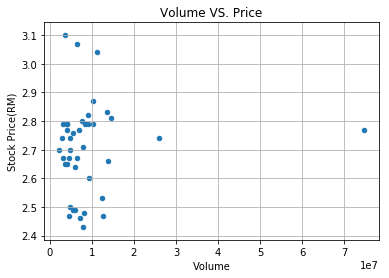

```python
C_stock1.plot(x='volume',y='price',kind='scatter')
plt.xlabel('Volume')
plt.ylabel('Stock Price(RM)')
plt.title('Volume VS. Price')
plt.grid(True)
```

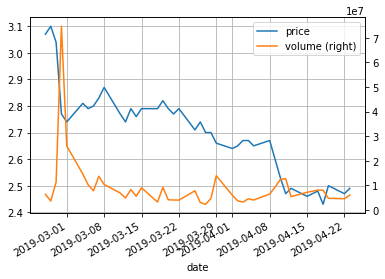

```python
C_stock1[['price','volume']].plot(secondary_y='volume', grid=True)
```

- To compare with the Stock Index

```python
ftse = pd.read_csv('https://raw.githubusercontent.com/WQD170071/Data-Mining-Project/master/Dataset/Milestone%204/FTSE%20Malaysia%20KLCI%20Historical%20Data.csv')
#setting index as date
ftse['Date'] = pd.to_datetime(ftse.Date,format='%Y-%m-%d')
ftse = ftse.sort_values(by = 'Date')
ftse.index = ftse['Date']
st_ft = C_stock1[['price']]
def ptoFloat(x):
    return float(x)

Price = ftse['Price'].apply(ptoFloat)
st_ft['SI_Price'] = Price
price = st_ft['price'].apply(ptoFloat)
st_ft['price'] = price
```

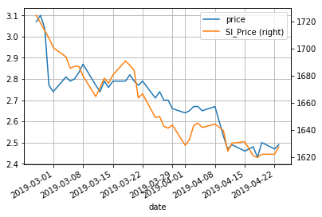

```python
st_ft[['price','SI_Price']].plot(secondary_y='SI_Price', grid=True)
```

- To compare with news

```python
# Merge stock price data and news sentiment data together for plotting
stock_news1 = pd.merge(C_stock1,C_news1,how='left',on='date')
# Fill NAs with value 0 in other to get a better visual
stock_news1['sentiment'] = stock_news1['sentiment'].fillna(0)
#setting index as date
stock_news1['date'] = pd.to_datetime(stock_news1.date,format='%Y-%m-%d')
stock_news1.index = stock_news1['date']
stock_news1
```

| date | name | code | date | open | low | high | price | volume | change | sentiment |
| --- | --- | --- | --- | --- | --- | --- | --- | --- | --- | --- |
| 2019-02-25 | AIRASIA GROUP BERHAD | 5099 | 2019-02-25 | 3.13 | 3.06 | 3.15 | 3.07 | 6375600.0 | 0.000000 | 0.0 |
| 2019-02-26 | AIRASIA GROUP BERHAD | 5099 | 2019-02-26 | 3.08 | 3.08 | 3.11 | 3.10 | 3629500.0 | 0.009772 | 0.0 |
| 2019-02-27 | AIRASIA GROUP BERHAD | 5099 | 2019-02-27 | 3.12 | 3.00 | 3.12 | 3.04 | 11274100.0 | -0.019355 | 0.0 |
| 2019-02-28 | AIRASIA GROUP BERHAD | 5099 | 2019-02-28 | 2.85 | 2.75 | 2.87 | 2.77 | 74676700.0 | -0.088816 | 0.0 |
| 2019-03-01 | AIRASIA GROUP BERHAD | 5099 | 2019-03-01 | 2.77 | 2.69 | 2.79 | 2.74 | 26015900.0 | -0.010830 | 0.0 |
| 2019-03-04 | AIRASIA GROUP BERHAD | 5099 | 2019-03-04 | 2.75 | 2.75 | 2.84 | 2.81 | 14608600.0 | 0.025547 | 0.0 |
| 2019-03-05 | AIRASIA GROUP BERHAD | 5099 | 2019-03-05 | 2.80 | 2.76 | 2.82 | 2.79 | 10219600.0 | -0.007117 | 0.0 |
| 2019-03-06 | AIRASIA GROUP BERHAD | 5099 | 2019-03-06 | 2.80 | 2.78 | 2.82 | 2.80 | 7779000.0 | 0.003584 | 0.0 |
| 2019-03-07 | AIRASIA GROUP BERHAD | 5099 | 2019-03-07 | 2.80 | 2.80 | 2.88 | 2.83 | 13683800.0 | 0.010714 | 0.0 |
| 2019-03-08 | AIRASIA GROUP BERHAD | 5099 | 2019-03-08 | 2.84 | 2.83 | 2.90 | 2.87 | 10360600.0 | 0.014134 | 0.0 |
| 2019-03-11 | AIRASIA GROUP BERHAD | 5099 | 2019-03-11 | 2.76 | 2.75 | 2.79 | 2.77 | 6888000.0 | -0.034843 | 0.0 |
| 2019-03-12 | AIRASIA GROUP BERHAD | 5099 | 2019-03-12 | 2.77 | 2.73 | 2.79 | 2.74 | 4854000.0 | -0.010830 | -1.0 |
| 2019-03-12 | AIRASIA GROUP BERHAD | 5099 | 2019-03-12 | 2.77 | 2.73 | 2.79 | 2.74 | 4854000.0 | -0.010830 | 1.0 |
| 2019-03-13 | AIRASIA GROUP BERHAD | 5099 | 2019-03-13 | 2.77 | 2.74 | 2.83 | 2.79 | 8284600.0 | 0.018248 | -1.0 |
| 2019-03-13 | AIRASIA GROUP BERHAD | 5099 | 2019-03-13 | 2.77 | 2.74 | 2.83 | 2.79 | 8284600.0 | 0.018248 | 1.0 |
| 2019-03-14 | AIRASIA GROUP BERHAD | 5099 | 2019-03-14 | 2.80 | 2.76 | 2.82 | 2.76 | 5593800.0 | -0.010753 | 0.0 |
| 2019-03-15 | AIRASIA GROUP BERHAD | 5099 | 2019-03-15 | 2.78 | 2.73 | 2.79 | 2.79 | 8984200.0 | 0.010870 | 1.0 |
| 2019-03-15 | AIRASIA GROUP BERHAD | 5099 | 2019-03-15 | 2.78 | 2.73 | 2.79 | 2.79 | 8984200.0 | 0.010870 | 1.0 |
| 2019-03-18 | AIRASIA GROUP BERHAD | 5099 | 2019-03-18 | 2.80 | 2.77 | 2.81 | 2.79 | 3230300.0 | 0.000000 | 1.0 |
| 2019-03-19 | AIRASIA GROUP BERHAD | 5099 | 2019-03-19 | 2.79 | 2.77 | 2.87 | 2.82 | 9212700.0 | 0.010753 | 0.0 |
| 2019-03-20 | AIRASIA GROUP BERHAD | 5099 | 2019-03-20 | 2.80 | 2.77 | 2.81 | 2.79 | 4135700.0 | -0.010638 | 0.0 |
| 2019-03-21 | AIRASIA GROUP BERHAD | 5099 | 2019-03-21 | 2.80 | 2.76 | 2.81 | 2.77 | 4049800.0 | -0.007168 | 0.0 |
| 2019-03-22 | AIRASIA GROUP BERHAD | 5099 | 2019-03-22 | 2.80 | 2.74 | 2.80 | 2.79 | 3998600.0 | 0.007220 | 0.0 |
| 2019-03-25 | AIRASIA GROUP BERHAD | 5099 | 2019-03-25 | 2.74 | 2.71 | 2.76 | 2.71 | 7800700.0 | -0.028674 | -1.0 |
| 2019-03-26 | AIRASIA GROUP BERHAD | 5099 | 2019-03-26 | 2.73 | 2.73 | 2.75 | 2.74 | 3008200.0 | 0.011070 | 0.0 |
| 2019-03-27 | AIRASIA GROUP BERHAD | 5099 | 2019-03-27 | 2.75 | 2.70 | 2.75 | 2.70 | 2300100.0 | -0.014599 | -1.0 |
| 2019-03-27 | AIRASIA GROUP BERHAD | 5099 | 2019-03-27 | 2.75 | 2.70 | 2.75 | 2.70 | 2300100.0 | -0.014599 | 0.0 |
| 2019-03-28 | AIRASIA GROUP BERHAD | 5099 | 2019-03-28 | 2.71 | 2.69 | 2.73 | 2.70 | 4727000.0 | 0.000000 | 0.0 |
| 2019-03-29 | AIRASIA GROUP BERHAD | 5099 | 2019-03-29 | 2.71 | 2.62 | 2.71 | 2.66 | 13900100.0 | -0.014815 | 0.0 |
| 2019-04-01 | AIRASIA GROUP BERHAD | 5099 | 2019-04-01 | 2.68 | 2.64 | 2.68 | 2.64 | 6005500.0 | -0.007519 | -1.0 |
| 2019-04-02 | AIRASIA GROUP BERHAD | 5099 | 2019-04-02 | 2.65 | 2.64 | 2.68 | 2.65 | 3738400.0 | 0.003788 | -1.0 |
| 2019-04-02 | AIRASIA GROUP BERHAD | 5099 | 2019-04-02 | 2.65 | 2.64 | 2.68 | 2.65 | 3738400.0 | 0.003788 | 0.0 |
| 2019-04-03 | AIRASIA GROUP BERHAD | 5099 | 2019-04-03 | 2.67 | 2.65 | 2.68 | 2.67 | 3208400.0 | 0.007547 | -1.0 |
| 2019-04-03 | AIRASIA GROUP BERHAD | 5099 | 2019-04-03 | 2.67 | 2.65 | 2.68 | 2.67 | 3208400.0 | 0.007547 | 0.0 |
| 2019-04-04 | AIRASIA GROUP BERHAD | 5099 | 2019-04-04 | 2.66 | 2.65 | 2.68 | 2.67 | 4548500.0 | 0.000000 | 0.0 |
| 2019-04-05 | AIRASIA GROUP BERHAD | 5099 | 2019-04-05 | 2.68 | 2.64 | 2.68 | 2.65 | 4045200.0 | -0.007491 | 0.0 |
| 2019-04-08 | AIRASIA GROUP BERHAD | 5099 | 2019-04-08 | 2.65 | 2.61 | 2.68 | 2.67 | 6462300.0 | 0.007547 | 1.0 |
| 2019-04-09 | AIRASIA GROUP BERHAD | 5099 | 2019-04-09 | 2.67 | 2.60 | 2.67 | 2.60 | 9284400.0 | -0.026217 | 0.0 |
| 2019-04-10 | AIRASIA GROUP BERHAD | 5099 | 2019-04-10 | 2.61 | 2.52 | 2.62 | 2.53 | 12435600.0 | -0.026923 | 0.0 |
| 2019-04-11 | AIRASIA GROUP BERHAD | 5099 | 2019-04-11 | 2.54 | 2.45 | 2.56 | 2.47 | 12700500.0 | -0.023715 | 0.0 |
| 2019-04-12 | AIRASIA GROUP BERHAD | 5099 | 2019-04-12 | 2.50 | 2.48 | 2.52 | 2.49 | 5411100.0 | 0.008097 | 0.0 |
| 2019-04-15 | AIRASIA GROUP BERHAD | 5099 | 2019-04-15 | 2.51 | 2.44 | 2.51 | 2.46 | 7177800.0 | -0.012048 | 0.0 |
| 2019-04-17 | AIRASIA GROUP BERHAD | 5099 | 2019-04-17 | 2.49 | 2.45 | 2.50 | 2.48 | 8080500.0 | 0.008130 | -1.0 |
| 2019-04-17 | AIRASIA GROUP BERHAD | 5099 | 2019-04-17 | 2.49 | 2.45 | 2.50 | 2.48 | 8080500.0 | 0.008130 | 1.0 |
| 2019-04-18 | AIRASIA GROUP BERHAD | 5099 | 2019-04-18 | 2.49 | 2.42 | 2.49 | 2.43 | 8010300.0 | -0.020161 | -1.0 |
| 2019-04-18 | AIRASIA GROUP BERHAD | 5099 | 2019-04-18 | 2.49 | 2.42 | 2.49 | 2.43 | 8010300.0 | -0.020161 | 0.0 |
| 2019-04-19 | AIRASIA GROUP BERHAD | 5099 | 2019-04-19 | 2.45 | 2.44 | 2.51 | 2.50 | 4727400.0 | 0.028807 | -1.0 |
| 2019-04-19 | AIRASIA GROUP BERHAD | 5099 | 2019-04-19 | 2.45 | 2.44 | 2.51 | 2.50 | 4727400.0 | 0.028807 | -1.0 |
| 2019-04-22 | AIRASIA GROUP BERHAD | 5099 | 2019-04-22 | 2.50 | 2.45 | 2.51 | 2.47 | 4565300.0 | -0.012000 | 0.0 |
| 2019-04-23 | AIRASIA GROUP BERHAD | 5099 | 2019-04-23 | 2.47 | 2.46 | 2.52 | 2.49 | 6047600.0 | 0.008097 | 0.0 |

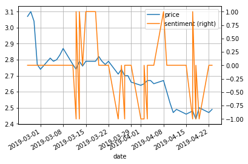

```python
# Compare price and sentiment
stock_news1[['price','sentiment']].plot(secondary_y='sentiment', grid=True)
```

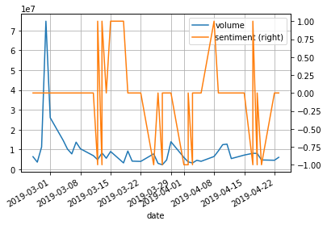

```python
# Compare volume and sentiment
stock_news1[['volume','sentiment']].plot(secondary_y='sentiment', grid=True)
```

- To compare with other stocks

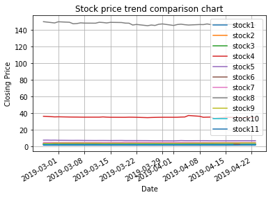

```python
# Create a dataframe that put all the stock price inside
closePrice = pd.DataFrame({"stock1": C_stock1["price"],
                           "stock2": C_stock2["price"],
                           "stock3": C_stock3["price"],
                           "stock4": C_stock4["price"],
                           "stock5": C_stock5["price"],
                           "stock6": C_stock6["price"],
                           "stock7": C_stock7["price"],
                           "stock8": C_stock8["price"],
                           "stock9": C_stock9["price"],
                           "stock10": C_stock10["price"],
                           "stock11": C_stock11["price"]})
# Plot all the stock price from the same sector
# Draw different stock prices on a graph.
# So that we can compare different stocks and compare the relationship between stocks and the market.
closePrice.plot(grid=True)
plt.xlabel('Date')
plt.ylabel('Closing Price')
plt.title('Stock price trend comparison chart')
```

- The problem of this graph: Although the absolute value of the price is important (expensive stocks are difficult to buy, this will not only affect their volatility but also affect the ease with which you trade them). But in the transaction, we pay more attention to the change in the price of each stock rather than its price.
- A "better" solution is to visualize the information we actually care about: the return of stocks, which requires us to make the necessary data transformations. There are many ways to convert data. One of the conversion methods is to compare the stock price of each trading day with the stock price starting from the time period we care about. That is:

  ```
   Return = Price(t) / Price(0)
  ```

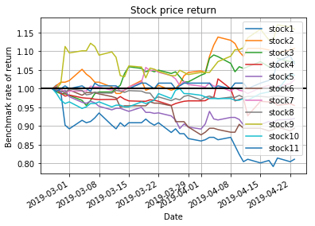

```python
# To plot the return of each stock
stock_return = closePrice.apply(lambda x: x / x[0])
stock_return.plot(grid = True).axhline(y = 1, color = "black", lw = 2)
plt.xlabel('Date')
plt.ylabel('Benchmark rate of return')
plt.title('Stock price return')
```

  ```
    Change(t) = log(price(t)) - log(price(t-1))
  ```

- The log here is the natural logarithm. The advantage of using a logarithmic difference is that the difference value can be interpreted as a percentage difference in the stock and is not affected by the denominator.

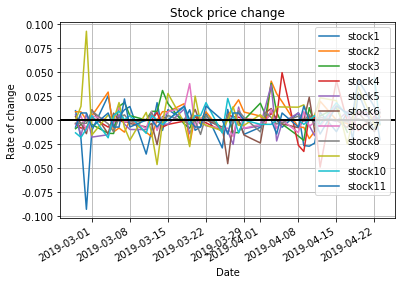

```python
# Plot all stock
stock_return = closePrice.apply(lambda x: np.log(x) - np.log(x.shift(1)))
stock_return.plot(grid = True).axhline(y = 0, color = "black", lw = 2)
plt.xlabel('Date')
plt.ylabel('Rate of change')
plt.title('Stock price change')
```

- From the income gap of the relative time period, the overall trend of different securities can be clearly seen.
- Correlation to other stocks

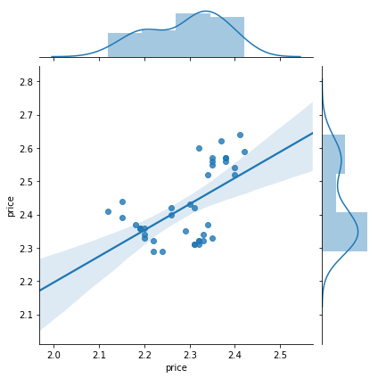

```python
import seaborn as sns
# Correlation between the first two stock
sns.jointplot(C_stock3.price, C_stock2.price, kind="reg")
```

```python
# We can also look at the correlation value:
np.corrcoef(C_stock3.price, C_stock2.price)
```

```
array([[1.       , 0.5839198],
       [0.5839198, 1.       ]])
```

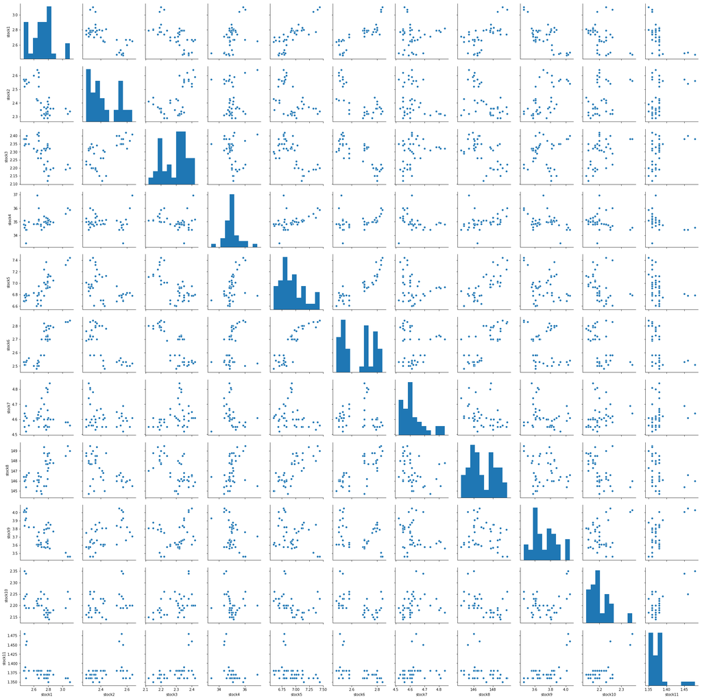

```python
# Make a stock correlation comparison for all companies
sns.pairplot(closePrice.dropna())
```

```python
import numpy as np
import math

class SAX_trans:

    def __init__(self, ts, w, alpha):
        self.ts = ts
        self.w = w
        self.alpha = alpha
        self.aOffset = ord('a')
        self.breakpoints = {'3' : [-0.43, 0.43],
                            '4' : [-0.67, 0, 0.67],
                            '5' : [-0.84, -0.25, 0.25, 0.84],
                            '6' : [-0.97, -0.43, 0, 0.43, 0.97],
                            '7' : [-1.07, -0.57, -0.18, 0.18, 0.57, 1.07],
                            '8' : [-1.15, -0.67, -0.32, 0, 0.32, 0.67, 1.15],

        }
        self.beta = self.breakpoints[str(self.alpha)]

    def normalize(self):
        X = np.asanyarray(self.ts)
        return (X - np.nanmean(X)) / np.nanstd(X)

    def paa_trans(self):
        tsn = self.normalize()
        paa_ts = []
        n = len(tsn)
        xk = math.ceil( n / self.w )
        for i in range(0,n,xk):
            temp_ts = tsn[i:i+xk]
            paa_ts.append(np.mean(temp_ts))
        return paa_ts

    def to_sax(self):
        tsn = self.paa_trans()
        len_tsn = len(tsn)
        len_beta = len(self.beta)
        strx = ''
        for i in range(len_tsn):
            letter_found = False
            for j in range(len_beta):
                if np.isnan(tsn[i]):
                    strx += '-'
                    letter_found = True
                    break
                if tsn[i] < self.beta[j]:
                    strx += chr(self.aOffset +j)
                    letter_found = True
                    break
            if not letter_found:
                strx += chr(self.aOffset + len_beta)
        return strx


    def compare_Dict(self):
        num_rep = range(self.alpha)
        letters = [chr(x + self.aOffset) for x in num_rep]
        compareDict = {}
        len_letters = len(letters)
        for i in range(len_letters):
            for j in range(len_letters):
                if np.abs(num_rep[i] - num_rep[j])<=1:
                    compareDict[letters[i]+letters[j]]=0
                else:
                    high_num = np.max([num_rep[i], num_rep[j]])-1
                    low_num = np.min([num_rep[i], num_rep[j]])
                    compareDict[letters[i]+letters[j]] = self.beta[high_num] - self.beta[low_num]
        return compareDict

    def dist(self, strx1,strx2):
        len_strx1 = len(strx1)
        len_strx2 = len(strx2)
        com_dict = self.compare_Dict()

        if len_strx1 != len_strx2:
            print("The length of the two strings does not match")
        else:
            list_letter_strx1 = [x for x in strx1]
            list_letter_strx2 = [x for x in strx2]
            mindist = 0.0
            for i in range(len_strx1):
                if list_letter_strx1[i] is not '-' and list_letter_strx2[i] is not '-':
                    mindist += (com_dict[list_letter_strx1[i] + list_letter_strx2[i]])**2
            mindist = np.sqrt((len(self.ts)*1.0)/ (self.w*1.0)) * np.sqrt(mindist)
            return mindist

ts1 = C_stock1['price'].values.tolist()
ts2 = C_stock2['price'].values.tolist()
ts3 = C_stock3['price'].values.tolist()
ts4 = C_stock4['price'].values.tolist()
ts5 = C_stock5['price'].values.tolist()
ts6 = C_stock6['price'].values.tolist()
ts7 = C_stock7['price'].values.tolist()
ts8 = C_stock8['price'].values.tolist()
ts9 = C_stock9['price'].values.tolist()
ts10 = C_stock10['price'].values.tolist()
ts11 = C_stock11['price'].values.tolist()
x1 = SAX_trans(ts=ts1,w=10,alpha=4)
x2 = SAX_trans(ts=ts2,w=10,alpha=4)
x3 = SAX_trans(ts=ts3,w=10,alpha=4)
x4 = SAX_trans(ts=ts4,w=10,alpha=4)
x5 = SAX_trans(ts=ts5,w=10,alpha=4)
x6 = SAX_trans(ts=ts6,w=10,alpha=4)
x7 = SAX_trans(ts=ts7,w=10,alpha=4)
x8 = SAX_trans(ts=ts8,w=10,alpha=4)
x9 = SAX_trans(ts=ts9,w=10,alpha=4)
x10 = SAX_trans(ts=ts10,w=10,alpha=4)
x11 = SAX_trans(ts=ts11,w=10,alpha=4)
st1 = x1.to_sax()
st2 = x2.to_sax()
st3 = x3.to_sax()
st4 = x4.to_sax()
st5 = x5.to_sax()
st6 = x6.to_sax()
st7 = x7.to_sax()
st8 = x8.to_sax()
st9 = x9.to_sax()
st10 = x10.to_sax()
st11 = x11.to_sax()
dist12 = x1.dist(st1,st2)
dist13 = x1.dist(st1,st3)
dist14 = x1.dist(st1,st4)
dist15 = x1.dist(st1,st5)
dist16 = x1.dist(st1,st6)
dist17 = x1.dist(st1,st7)
dist18 = x1.dist(st1,st8)
dist19 = x1.dist(st1,st9)
dist110 = x1.dist(st1,st10)
dist111 = x1.dist(st1,st11)
dist23 = x2.dist(st2,st3)
dist24 = x2.dist(st2,st4)
dist25 = x2.dist(st2,st5)
dist26 = x2.dist(st2,st6)
dist27 = x2.dist(st2,st7)
dist28 = x2.dist(st2,st8)
dist29 = x2.dist(st2,st9)
dist210 = x2.dist(st2,st10)
dist211 = x2.dist(st2,st11)
dist34 = x3.dist(st3,st4)
dist35 = x3.dist(st3,st5)
dist36 = x3.dist(st3,st6)
dist37 = x3.dist(st3,st7)
dist38 = x3.dist(st3,st8)
dist39 = x3.dist(st3,st9)
dist310 = x3.dist(st3,st10)
dist311 = x3.dist(st3,st11)
dist45 = x4.dist(st4,st5)
dist46 = x4.dist(st4,st6)
dist47 = x4.dist(st4,st7)
dist48 = x4.dist(st4,st8)
dist49 = x4.dist(st4,st9)
dist410 = x4.dist(st4,st10)
dist411 = x4.dist(st4,st11)
dist56 = x5.dist(st5,st6)
dist57 = x5.dist(st5,st7)
dist58 = x5.dist(st5,st8)
dist59 = x5.dist(st5,st9)
dist510 = x5.dist(st5,st10)
dist511 = x5.dist(st5,st11)
dist67 = x6.dist(st6,st7)
dist68 = x6.dist(st6,st8)
dist69 = x6.dist(st6,st9)
dist610 = x6.dist(st6,st10)
dist611 = x6.dist(st6,st11)
dist78 = x7.dist(st7,st8)
dist79 = x7.dist(st7,st9)
dist710 = x7.dist(st7,st10)
dist711 = x7.dist(st7,st11)
dist89 = x8.dist(st8,st9)
dist810 = x8.dist(st8,st10)
dist811 = x8.dist(st8,st11)
dist910 = x9.dist(st9,st10)
dist911 = x9.dist(st9,st11)
dist1011 = x10.dist(st10,st11)
print('st1',st1)
print('st2',st2)
print('st3',st3)
print('st4',st4)
print('st5',st5)
print('st6',st6)
print('st7',st7)
print('st8',st8)
print('st9',st9)
print('st10',st10)
print('st11',st11)
print('dist12',dist12)
print('dist13',dist13)
print('dist14',dist14)
print('dist15',dist15)
print('dist16',dist16)
print('dist17',dist17)
print('dist18',dist18)
print('dist19',dist19)
print('dist110',dist110)
print('dist111',dist111)
print('dist23',dist23)
print('dist24',dist24)
print('dist25',dist25)
print('dist26',dist26)
print('dist27',dist27)
print('dist28',dist28)
print('dist29',dist29)
print('dist210',dist210)
print('dist211',dist211)
print('dist34',dist34)
print('dist35',dist35)
print('dist36',dist36)
print('dist37',dist37)
print('dist38',dist38)
print('dist39',dist39)
print('dist310',dist310)
print('dist311',dist311)
print('dist45',dist45)
print('dist46',dist46)
print('dist47',dist47)
print('dist48',dist48)
print('dist49',dist49)
print('dist410',dist410)
print('dist411',dist411)
print('dist56',dist56)
print('dist57',dist57)
print('dist58',dist58)
print('dist59',dist59)
print('dist510',dist510)
print('dist511',dist511)
print('dist67',dist67)
print('dist68',dist68)
print('dist69',dist69)
print('dist610',dist610)
print('dist611',dist611)
print('dist78',dist78)
print('dist79',dist79)
print('dist710',dist710)
print('dist711',dist711)
print('dist89',dist89)
print('dist810',dist810)
print('dist811',dist811)
print('dist910',dist910)
print('dist911',dist911)
print('dist1011',dist1011)
```

```
The length of the two strings does not match
The length of the two strings does not match
The length of the two strings does not match
The length of the two strings does not match
The length of the two strings does not match
The length of the two strings does not match
The length of the two strings does not match
The length of the two strings does not match
The length of the two strings does not match
The length of the two strings does not match
The length of the two strings does not match
The length of the two strings does not match
The length of the two strings does not match
The length of the two strings does not match
The length of the two strings does not match
The length of the two strings does not match
The length of the two strings does not match
The length of the two strings does not match
The length of the two strings does not match
The length of the two strings does not match
The length of the two strings does not match
The length of the two strings does not match
The length of the two strings does not match
The length of the two strings does not match
st1 ddccbbaaa
st2 abaaaacddd
st3 aaaccccddd
st4 dccbbdbba
st5 ddccaaaab
st6 ddccbaaaa
st7 abbddbabd
st8 dcdcaabba
st9 acbaabcdd
st10 caaabdcbbd
st11 bbbbbbbdd
dist12 None
dist13 None
dist14 1.3566466009982112
dist15 0.0
dist16 0.0
```

[output cut: 35 more lines]

```
dist67 4.290093239080008
dist68 0.0
dist69 5.076106775866717
dist610 None
dist611 4.290093239080008
dist78 4.891458882582986
dist79 4.290093239080008
dist710 None
dist711 2.349780840844524
dist89 4.499487748622058
dist810 None
dist811 3.589349523242338
dist910 None
dist911 0.0
dist1011 None
```